# Predicting Arsenic Exceedance in Private Wells

Hansen Xie, Lingye Meng, Rujie Cheng

May 12, 2026

# 1 Executive Summary

**Project Website:** https://arsenic-wells-site.vercel.app/

**Problem Statement:** Private well arsenic risk can remain undetected because private wells are not routinely monitored through public water systems. This creates an incomplete picture of where elevated arsenic risk may be more likely and where testing outreach may be most needed.

**Use Case:** This project documents a reproducible machine-learning workflow for estimating relative elevated arsenic risk in Gaston County private wells. The workflow is designed to support a risk map, follow-up testing priority, and public-facing risk communication; it is not a direct water test or confirmation of contamination at an individual well.

**Key Data Challenges:** The cleaned dataset includes 1,708 wells. Using the project threshold of arsenic at or above 5 μg/L, 118 wells are coded as exceedance cases, or 6.9% of the sample. Because arsenic exceedance cases are rare, accuracy alone is misleading; the workflow focuses instead on ROC-AUC and threshold-based metrics such as sensitivity, precision, specificity, false negatives, false positives, and flagged wells.

**Modeling Solution:** The analysis compares random forest, GBM, and glmnet models across full/exploratory and simplified/interpretable feature sets using 20 repeated holdout evaluations. Upsampling is applied only inside the training data, while held-out test data remain unchanged to preserve the real risk-prioritization context.

**Model Performance and Risk Views:** The final results are organized into three risk views rather than one universal “best” model: Broad Screening View (technical package: Screening-First), Strict Confirmation View (technical package: Confirmation-First), and Public Explanation View (technical package: Explanation-First). Across 20 repeated holdout evaluations, Explanation-First has the highest mean ROC-AUC among the final packages. Explanation-First remains the recommended public-facing default because it balances communication, interpretability, and strong model performance.

**Website Deliverable:** The final website translates the selected package outputs into a public-facing risk map and decision-support tool: https://arsenic-wells-site.vercel.app/. It helps users explore predicted elevated arsenic risk patterns and understand where follow-up testing may be valuable, without presenting the model as a direct water test.

**Limitations:** The model supports risk prioritization and testing attention, not laboratory confirmation. The small number of positive cases, possible spatial dependence, and missing hydrogeologic variables limit how confidently the results can be generalized.

# 2 Background

Chronic exposure to elevated arsenic in drinking water is a serious public health concern. Arsenic exposure above the [U.S. Environmental Protection Agency drinking water standard of 10 μg/L](https://www.epa.gov/dwreginfo/chemical-contaminant-rules) has been associated with several cancers, including lung, bladder, and prostate cancer, as well as other long-term health risks. For modeling and website communication, this project uses 5 μg/L as the threshold for elevated arsenic. This is lower than the federal drinking water standard of 10 μg/L, but it reflects the testing method’s detection limit and supports a more precautionary risk-screening approach. This issue is especially important for households that rely on private wells, because private wells are not routinely monitored through the same regulatory systems as public water supplies. As a result, arsenic risks may remain undetected unless individual well owners choose to test their water. Predictive modeling can help address this information gap by identifying areas where elevated arsenic is more likely to occur and where testing outreach may be most needed.

In the United States, [over 43 million people, or more than 15% of the total population](https://www.epa.gov/privatewells), rely on private wells, and an estimated 2.1 million people use groundwater with arsenic concentrations above the federal drinking water standard. However, private well testing data are often limited, unevenly distributed, and difficult to use for proactive risk identification. Machine learning offers a potential way to address this gap by using available environmental, geological, and spatial information to predict where elevated arsenic concentrations are more likely to occur.

This project applies machine learning methods to estimate relative elevated arsenic risk in private wells in Gaston County, North Carolina. Gaston County provides a useful case study because it includes both urban and rural areas and has a substantial population relying on private well water. The county had a [population of 227,943, with 94,383 households and a median household income of $70,182](https://data.census.gov/profile/Gaston_County,_North_Carolina?g=050XX00US37071). About 80% of residents live in urban areas, while approximately 42% rely on private wells. The observed arsenic data also show clear spatial heterogeneity, with detectable arsenic levels, defined in this project as concentrations at or above 5 μg/L, clustering more strongly in the northwestern part of the county.

Using this context, the project aims to develop and evaluate predictive models that can help identify wells and areas with elevated predicted arsenic risk. The final output is intended to support a public-facing risk map, risk communication, and follow-up testing prioritization so residents, planners, and public health practitioners can better understand where private well testing and outreach may be most needed.

# 3 Exploratory Data Analysis and Feature Foundations

This section uses exploratory analysis to explain how the private-well dataset was prepared for modeling and why the modeling workflow is best understood as risk prioritization for follow-up testing. Screening means using model predictions to prioritize follow-up arsenic testing or closer review; it does not mean confirming contamination at an individual well. Rather than treating the data as a generic classification exercise, we first examine the cleaned sample, the rarity of exceedance cases, and the predictor families that could plausibly help rank wells for follow-up testing. These patterns provide the foundation for the feature engineering and package design decisions developed in later sections.

## 3.1 Data snapshot and screening logic

The raw well dataset was cleaned by removing invalid terrain records, leaving 1708 usable private well records for analysis. Each record represents one private well, and the screening outcome indicates whether that well is coded as an arsenic exceedance or non-exceedance.

The cleaned sample shows a clear rare-event problem: only 118 of 1,708 wells, or 6.9%, are coded as arsenic exceedance cases. Because the positive class is so small, raw accuracy can be misleading—a model could appear accurate while still missing many wells that may warrant testing attention.

The figures below summarize the cleaned sample and the evaluation logic that follows from the imbalance problem.

Cleaned sample size

1,708

Positive cases

118

Negative cases

1,590

Positive share

6.9%

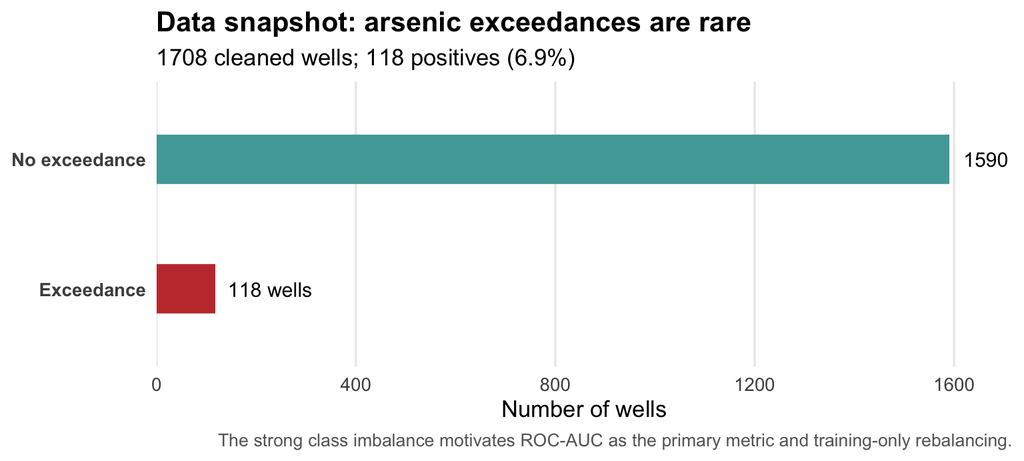

For this reason, the workflow treats the model as a screening and decision-support tool rather than a direct testing tool. ROC-AUC is used as the primary metric because it evaluates how well the model ranks wells with higher observed arsenic concern across thresholds. To address class imbalance, upsampling is applied only to the training data, while the held-out test set remains unchanged so evaluation reflects the real risk-prioritization context.

The workflow diagram below shows how the evaluation strategy protects the rare-event screening context.

Cleaned data

↓

Train/test split

↓

Training set: upsampled before fitting

↓

Test set: untouched for realistic evaluation

↓

ROC-AUC plus threshold metrics

Together, these patterns define the modeling task as a screening workflow: the model should help prioritize wells for follow-up testing, while laboratory testing remains necessary for confirming household-level water quality conditions.

## 3.2 Feature engineering and predictor foundations

Arsenic exceedance is unlikely to be explained by one predictor alone. It may reflect a combination of physical setting, water chemistry, nearby environmental context, and spatial structure. For that reason, the candidate predictors were organized into several families before modeling: terrain and topography, water chemistry, proximity and context, spatial context, and engineered chemistry ratios.

These families matter because they capture different pieces of the screening problem. Terrain and topography describe physical and groundwater setting; proximity variables capture nearby environmental or land-context signals; hydrochemistry describes measured water conditions; spatial context accounts for sampling density and broader spatial structure; and ratios summarize meaningful relationships among chemistry variables. The table and cards below summarize this predictor foundation without treating any single variable group as sufficient on its own.

Predictor families and their role in arsenic risk screening.

| Predictor family | Examples | Screening rationale | Final workflow role |
| --- | --- | --- | --- |
| Topography and terrain | DEM, Slope, TPI, TRI, TWI, Curvature | Terrain affects groundwater flow, accumulation, and geologic exposure pathways. | Yes |
| Hazard and land-context proximity | DistBrown, DisHazSite, DisRUST, DisCoalAsh, DisDam, DisALa | Distances represent proximity to features that may indicate environmental context or potential contaminant sources. | Yes |
| Hydrochemistry | pH/newPH, Hardness, Alkalinity, Calcium, Magnesium, Iron, Manganese, Sulfate, Nitrate, Chloride | Water chemistry can reflect redox, mineral dissolution, and other geochemical conditions associated with arsenic mobility. | Yes |
| Well density and spatial context | DensityWel, AutoCov, mica | Local density and spatial covariates help capture sampling context and spatial structure not fully described by chemistry alone. | Yes |
| Interpretable ratios | Ca_Mg_ratio, Na_Cl_ratio, Fe_Mn_ratio | Ratios summarize chemically meaningful relationships while keeping the final workflow readable. | Final retained workflow |

The selected distributions below show that several predictors are highly uneven across wells. Distance and chemistry variables in particular have long tails, which justified testing transformations and alternative feature representations. At the same time, the final feature story needs to remain interpretable and communicable for screening use, so the retained foundation emphasizes predictor families and chemically meaningful ratios.

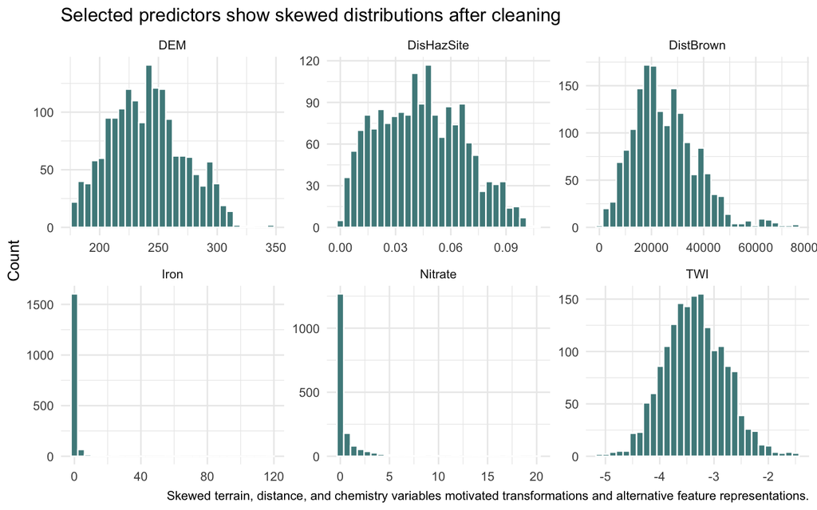

Transformations remain part of the modeling foundation, but they are framed as candidate representations rather than as the main story. The table below summarizes the additional transformations considered alongside the interpretable chemistry ratios.

Additional transformations considered for the full feature representation.

| Engineering family | Examples | Final role |
| --- | --- | --- |
| Log transforms | log_* variables for skewed numeric predictors | Full / exploratory representation |
| Squared terms | DEM_sq, Slope_sq, TWI_sq, chemistry squared terms where present | Full / exploratory representation |
| Additional ratios | SO4_Cl_ratio, Hard_Alk_ratio, NO3_SO4_ratio, TRI_TPI_ratio, Slope_TWI_ratio | Full / exploratory representation |
| Interaction terms | DEM_x_DistBrown, Slope_x_TWI, pH_x_Hardness, pH_x_Iron, WellDens_x_Nitrate | Full / exploratory representation |

The interpretable chemistry-ratio features are retained because they are easy to communicate and represent meaningful relationships among related water-chemistry measures. These ratios help connect feature engineering back to screening interpretation rather than adding complexity for its own sake.

Interpretable ratio feature cards retained in the simplified feature representation.

| Feature | Formula | Interpretation |
| --- | --- | --- |
| `Ca_Mg_ratio` | `Calcium / (Magnesium + 0.01)` | Relative mineral chemistry signal |
| `Na_Cl_ratio` | `Sodium / (Chloride + 0.01)` | Ionic balance and salinity-related signal |
| `Fe_Mn_ratio` | `Iron / (Manganese + 0.001)` | Redox-related geochemical signal |

Before modeling, feature screening reduces noise and redundancy. Near-zero variance removal removes low-information predictors, while correlation filtering reduces duplicated numeric signals. This process preserves two feature representations for package comparison: a simplified/interpretable representation and a full/exploratory representation.

Feature selection summary for the retained package workflow.

| Feature selection step | Purpose | Output |
| --- | --- | --- |
| Near-zero variance removal | Remove uninformative variables | Cleaner candidate set |
| Correlation filtering | Reduce redundant numeric predictors | Less duplicated signal |
| Keep-original strategy | Preserve interpretability where engineered and original variables overlap | Original variables retained when possible |
| Final feature sets | Support package design | Simplified/interpretable plus full/exploratory representations |

Final feature representations carried into exploratory modeling and package evaluation.

| Feature representation | Dataset object | Predictors after screening | Engineered features after screening |
| --- | --- | --- | --- |
| Simplified / interpretable | df_interpretable | 29 | 3 |
| Full / exploratory | df_full | 52 | 27 |

The pipeline below summarizes how the project moves from raw candidate predictors to feature representations used in package modeling.

Raw predictor families  
30 candidate predictors

↓

Interpretable ratios and transformations  
chemistry ratios plus tested transformations

↓

Redundancy screening  
remove low-information and duplicated signal

↓

Retained feature representations  
simplified/interpretable and full/exploratory

↓

Package modeling  
feature sets paired with model families and thresholds

# 4 Model Development and Package Selection

To decide which model configurations should become final screening packages, the workflow first compared candidate model-feature configurations, then examined threshold behavior, and finally selected package roles for different screening needs. ROC-AUC is used to compare risk-ranking discrimination, while threshold-specific metrics translate predicted probabilities into follow-up testing burden and missed-exceedance trade-offs.

## 4.1 Comparing model-feature configurations

The first modeling decision was not simply which algorithm performed best, but which combination of model family and feature representation provided the most useful risk-ranking and follow-up-testing behavior. The candidate comparison crossed three model families with two feature representations: random forest, GBM, and `glmnet` were each considered with the full/exploratory and simplified/interpretable feature sets. ROC-AUC is used here because the rare-event screening question is whether wells with higher observed arsenic concern are ranked ahead of lower-risk wells before a final cutoff is chosen.

The table below summarizes the six model-feature candidates evaluated before final package selection. GBM is included as a boosted benchmark, even though it was not retained for the final package workflow.

Candidate model-feature comparison and final package roles.

| Feature representation | Model | Iterations | Mean ROC-AUC | SD ROC-AUC | 95% CI lower | 95% CI upper | Final role |
| --- | --- | --- | --- | --- | --- | --- | --- |
| Full / exploratory | Random Forest | 20 | 0.855 | 0.029 | 0.842 | 0.867 | Retained for Confirmation-First |
| Full / exploratory | GBM | 20 | 0.839 | 0.042 | 0.821 | 0.857 | Evaluated as boosted benchmark; not retained |
| Full / exploratory | glmnet | 20 | 0.818 | 0.034 | 0.803 | 0.833 | Evaluated as candidate; not retained |
| Simplified / interpretable | Random Forest | 20 | 0.863 | 0.028 | 0.850 | 0.875 | Retained for Explanation-First |
| Simplified / interpretable | GBM | 20 | 0.848 | 0.026 | 0.836 | 0.859 | Evaluated as boosted benchmark; not retained |
| Simplified / interpretable | glmnet | 20 | 0.827 | 0.028 | 0.815 | 0.839 | Retained for Screening-First |

The ROC curves below show the same six candidate configurations. Faceting keeps the boosted, random forest, and regularized models visible under both feature representations without relying on a long legend.

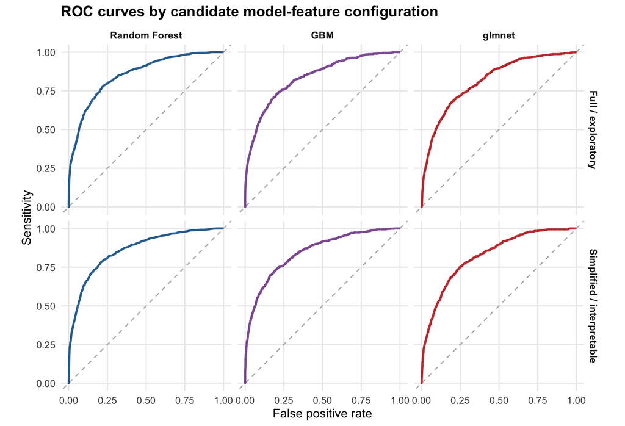

Across 20 repeated holdout evaluations, the strongest candidate configuration by mean ROC-AUC is Random Forest + simplified / interpretable (0.863, SD 0.028). The retained random forest configurations remain important because they provide nonlinear discrimination for the explanation-oriented and confirmation-oriented packages. GBM is kept as a boosted benchmark but is not retained because it does not provide a clearer operational role than the final random forest or `glmnet` options. Although `glmnet` has lower ROC-AUC than the strongest retained nonlinear model, it remains useful as a transparent regularized option for broad screening.

## 4.2 Threshold trade-offs and operating postures

After comparing model-feature configurations, the next decision was how predicted probabilities should be converted into risk flags for follow-up testing priority. The threshold controls the operational posture of the screening tool: lower thresholds cast a wider net and flag more wells for testing attention, while higher thresholds produce more selective flags but miss more observed exceedance cases.

The table below shows the full threshold comparison from 0.10 to 0.70 for each retained model-feature configuration.

Full threshold operating comparison across retained model-feature configurations.

| Feature representation | Model | Threshold | Mean sensitivity | Mean precision | Mean specificity | Mean accuracy | Mean false negatives | Mean false positives | Mean flagged wells |
| --- | --- | --- | --- | --- | --- | --- | --- | --- | --- |
| Full / exploratory | Random Forest | 0.10 | 0.830 | 0.179 | 0.720 | 0.727 | 6.0 | 133.7 | 162.8 |
| Full / exploratory | Random Forest | 0.20 | 0.573 | 0.315 | 0.908 | 0.885 | 14.9 | 43.7 | 63.8 |
| Full / exploratory | Random Forest | 0.30 | 0.374 | 0.477 | 0.970 | 0.929 | 21.9 | 14.5 | 27.6 |
| Full / exploratory | Random Forest | 0.40 | 0.253 | 0.639 | 0.989 | 0.939 | 26.1 | 5.2 | 14.0 |
| Full / exploratory | Random Forest | 0.50 | 0.167 | 0.822 | 0.997 | 0.941 | 29.1 | 1.2 | 7.1 |
| Full / exploratory | Random Forest | 0.60 | 0.090 | 0.926 | 0.999 | 0.937 | 31.9 | 0.3 | 3.5 |
| Full / exploratory | Random Forest | 0.70 | 0.040 | 0.958 | 1.000 | 0.934 | 33.6 | 0.1 | 1.5 |
| Simplified / interpretable | Random Forest | 0.10 | 0.850 | 0.205 | 0.758 | 0.764 | 5.2 | 115.6 | 145.3 |
| Simplified / interpretable | Random Forest | 0.20 | 0.613 | 0.353 | 0.917 | 0.896 | 13.6 | 39.7 | 61.1 |
| Simplified / interpretable | Random Forest | 0.30 | 0.394 | 0.474 | 0.968 | 0.929 | 21.2 | 15.3 | 29.1 |
| Simplified / interpretable | Random Forest | 0.40 | 0.306 | 0.630 | 0.986 | 0.940 | 24.3 | 6.4 | 17.1 |
| Simplified / interpretable | Random Forest | 0.50 | 0.237 | 0.776 | 0.995 | 0.943 | 26.7 | 2.4 | 10.7 |
| Simplified / interpretable | Random Forest | 0.60 | 0.153 | 0.886 | 0.999 | 0.941 | 29.6 | 0.7 | 6.0 |
| Simplified / interpretable | Random Forest | 0.70 | 0.081 | 0.931 | 0.999 | 0.937 | 32.1 | 0.2 | 3.1 |
| Simplified / interpretable | glmnet | 0.10 | 0.963 | 0.091 | 0.295 | 0.341 | 1.3 | 336.2 | 369.9 |
| Simplified / interpretable | glmnet | 0.20 | 0.900 | 0.112 | 0.478 | 0.507 | 3.5 | 248.9 | 280.4 |
| Simplified / interpretable | glmnet | 0.30 | 0.811 | 0.140 | 0.632 | 0.644 | 6.6 | 175.4 | 203.8 |
| Simplified / interpretable | glmnet | 0.40 | 0.736 | 0.170 | 0.736 | 0.736 | 9.2 | 126.1 | 151.8 |
| Simplified / interpretable | glmnet | 0.50 | 0.680 | 0.210 | 0.812 | 0.803 | 11.2 | 89.5 | 113.3 |
| Simplified / interpretable | glmnet | 0.60 | 0.610 | 0.244 | 0.860 | 0.843 | 13.7 | 66.8 | 88.1 |
| Simplified / interpretable | glmnet | 0.70 | 0.521 | 0.289 | 0.905 | 0.879 | 16.8 | 45.5 | 63.7 |

The plot below summarizes the main operating trade-off across the same threshold range.

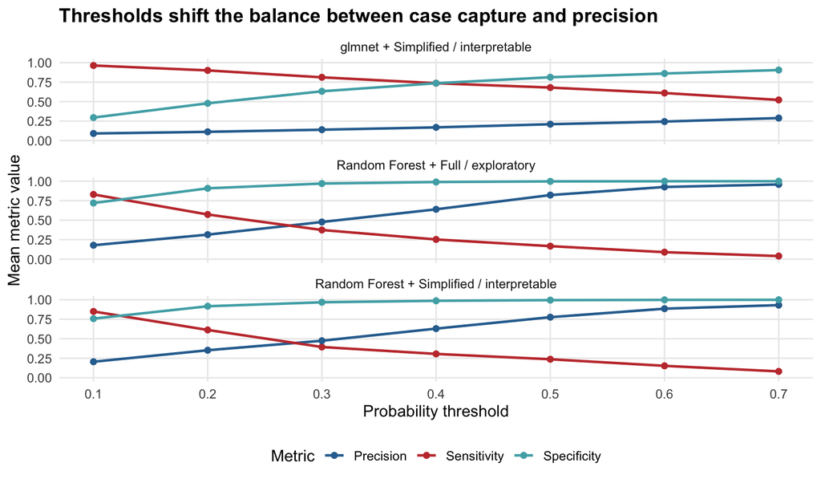

The comparisons show why no single configuration is best for every operational goal. The rare-event screening problem requires attention to missed exceedances and follow-up burden; random forest provides the strongest nonlinear-discrimination role; `glmnet` provides a transparent regularized screening option; the two feature representations serve different communication and performance needs; and thresholds define different operating postures.

## 4.3 From threshold evidence to final package choices

Based on the full threshold comparison, three thresholds were retained as representative operating postures. They are not treated as one universal optimum; instead, each corresponds to a different screening use case.

Representative thresholds selected for the final package design.

| Threshold | Package | Mean sensitivity | Mean precision | Mean specificity | Mean flagged wells | Operational interpretation |
| --- | --- | --- | --- | --- | --- | --- |
| 0.20 | Screening-First | 0.900 | 0.112 | 0.478 | 280.4 | Broad screening; catches more possible exceedance wells but increases follow-up burden. |
| 0.50 | Confirmation-First | 0.167 | 0.822 | 0.997 | 7.1 | Conservative confirmation; produces fewer, higher-confidence flags. |
| 0.30 | Explanation-First | 0.394 | 0.474 | 0.968 | 29.1 | Middle ground between case capture and follow-up burden. |

The 0.20 threshold represents a broad screening posture for users who are more concerned about missing true exceedance wells. The 0.30 threshold represents a middle-ground explanation-oriented posture that balances case capture and follow-up burden. The 0.50 threshold represents a conservative confirmation posture for users who want fewer, higher-confidence flags.

These model, feature, and threshold decisions define the three final screening packages evaluated in Section 5.

# 5 Final Screening Packages and Operational Evaluation

This section translates the model-development evidence into three operational arsenic risk views. The packages are not ranked from best to worst; each starts from a different screening decision: catch more possible exceedance wells, flag only the strongest predicted risk signals, or provide a clearer risk pattern for public communication.

## 5.1 Three final arsenic risk views

Model metrics are reported below, but the first step is to choose the risk view that best fits the screening decision.

Screening-First

Broad Screening View

**Best question:** What if I do not want to miss wells that may need testing attention?

**Configuration:** glmnet + Simplified / interpretable, threshold 0.20

**Meaning:** More wells are flagged for possible follow-up, including more false alarms.

**Main trade-off:** Catches more possible exceedance wells, but increases follow-up burden.

Confirmation-First

Focused screening View

**Best question:** What if I only want to flag wells with very strong evidence?

**Configuration:** Random Forest + Full / exploratory, threshold 0.50

**Meaning:** Only the strongest predicted risk signals are highlighted.

**Main trade-off:** Produces fewer, higher-confidence flags, but misses more true exceedance wells.

Explanation-First

Simplified inputs View

**Best question:** What if I need a risk pattern that is easier to explain?

**Configuration:** Random Forest + Simplified / interpretable, threshold 0.30

**Meaning:** The result is easier to communicate while still performing strongly overall.

**Main trade-off:** Balances communication, interpretability, and model performance.

These three views are designed for different decision contexts rather than different levels of model quality. Broad Screening View (technical package: Screening-First) prioritizes case capture, Focused screening View (technical package: Confirmation-First) prioritizes more selective risk flags, and Simplified inputs View (technical package: Explanation-First) provides the most practical default for communication-oriented use.

## 5.2 Package comparison, recommended default, and interpretation limits

The table below compares the three final packages using their selected operating thresholds. ROC-AUC summarizes overall ranking ability, while sensitivity, precision, specificity, and flagged wells describe the practical screening trade-offs after a threshold is applied.

Final screening packages and selected operating behavior.

| Package | Public-facing name | Model / feature representation | Threshold | Mean ROC-AUC | Mean sensitivity | Mean precision | Mean specificity | Mean accuracy | Mean false negatives | Mean false positives | Mean flagged wells | Main use case / trade-off |
| --- | --- | --- | --- | --- | --- | --- | --- | --- | --- | --- | --- | --- |
| Screening-First | Broad Screening View | glmnet + simplified / interpretable | 0.20 | 0.827 | 0.900 | 0.112 | 0.478 | 0.507 | 3.5 | 248.9 | 280.4 | Use when missed possible exceedance wells are the main concern; expect more follow-up. |
| Explanation-First | Simplified inputs View | Random Forest + simplified / interpretable | 0.30 | 0.863 | 0.394 | 0.474 | 0.968 | 0.929 | 21.2 | 15.3 | 29.1 | Use as the default public-facing view; easier to explain while performing strongly. |
| Confirmation-First | Focused screening View | Random Forest + full / exploratory | 0.50 | 0.855 | 0.167 | 0.822 | 0.997 | 0.941 | 29.1 | 1.2 | 7.1 | Use when false alarms are costly; expect fewer but stricter flags. |

The Broad Screening View (technical package: Screening-First) has the most precautionary posture because it flags more wells for possible follow-up. The Focused screening View (technical package: Confirmation-First) is the most conservative posture because it highlights only the strongest predicted risk signals. The Public Explanation View (technical package: Explanation-First) sits between those two use cases and is designed for clearer public-facing interpretation.

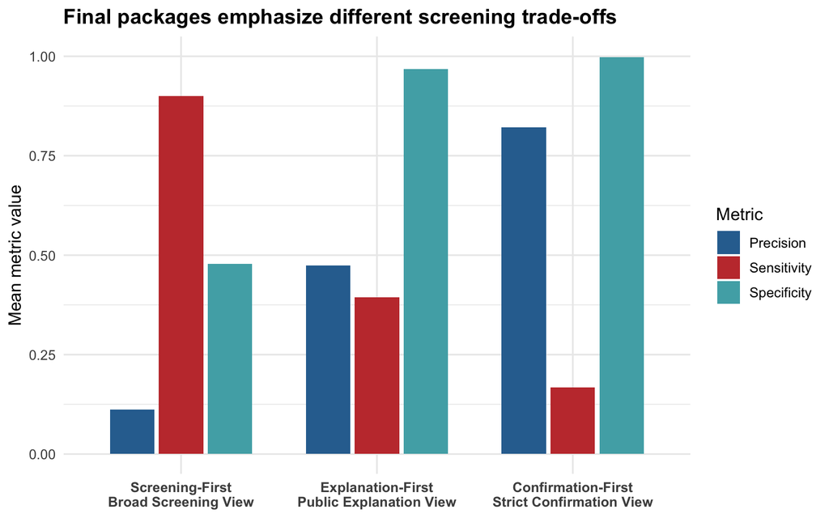

For public communication and general website use, the Explanation-First / Simplified inputs View remains the most practical default. The other two views remain useful when the decision context changes: Broad Screening View is appropriate when missing possible exceedance wells is the main concern, while Focused screening View is appropriate when false alarms are costly.

The package evaluation tables report average held-out test-set metrics across 20 repeated evaluations. The website map reports full-dataset flag counts after applying each selected package to all 1,708 cleaned wells.

These packages support risk prioritization; they do not replace laboratory testing. A risk flag should be interpreted as a priority for follow-up testing, not as confirmed contamination. Wells without a flag may still warrant testing based on household concerns, local knowledge, or other public-health guidance. These packages are best used to organize outreach, sampling queues, and communication priorities under resource constraints.

## 5.3 Spatial patterns of the three final packages

The maps below show how the three final screening packages assign risk flags across Gaston County under their selected operating thresholds. They are intended to show the spatial implications of each screening posture rather than to serve as a direct water test for any individual well.

**Broad Screening View**

[interactive chart not shown]

**Focused screening View**

[interactive chart not shown]

**Simplified inputs View**

[interactive chart not shown]

Broad Screening View produces the broadest spatial flagging pattern and is most useful when missed exceedances are the main concern. Strict Confirmation View is the most selective and highlights only the strongest predicted risk signals. Simplified inputs View sits between these two approaches and is the most practical public-facing default because it keeps the result easier to communicate while maintaining strong overall performance.

## 5.4 Website

As the final project deliverable, we developed an interactive public-facing risk map and decision-support resource: https://arsenic-wells-site.vercel.app/

This report documents the data cleaning, feature engineering, model comparison, threshold evaluation, and final package selection. The website translates those final package outputs into three operational risk views—Broad Screening View, Focused screening View, and Public Explanation View—so users can choose a view based on their goal, explore predicted elevated arsenic risk patterns, and understand where follow-up testing may be valuable. It does not present the model as a direct water test or final proof of contamination at an individual well.

# 6 Findings, Practical Implications, and Limitations

The final model workflow should be understood as a screening and prioritization tool rather than a household-level testing system. Its main value is not to determine household-level water quality, but to help rank wells by relative arsenic concern and identify where follow-up testing, outreach, or communication may be most needed. This distinction is important because the project is designed for a rare-event public-health context: the model can support better targeting of limited testing resources, but laboratory testing remains necessary for confirmation.

## 6.1 Findings and field use

The three final screening packages translate the model evidence into different operational choices. The Broad Screening View is appropriate when the main concern is missing possible exceedance wells; it flags more wells for follow-up and accepts a higher false-alarm burden. The Focused screening View is appropriate when testing capacity is limited or when risk flags should be used conservatively; it flags fewer wells but misses more possible exceedance cases. The Simplified inputs View provides the most practical default for public communication because it balances model performance, interpretability, and a more understandable risk pattern.

In practice, the model could be used to create a prioritized list of wells for arsenic sampling, mailed testing reminders, or targeted household communication. Local agencies or project partners should review model outputs alongside local knowledge, known vulnerable households, recent sampling history, and available testing resources. The threshold should therefore be treated as an operational decision tied to staffing, testing budgets, and risk tolerance, not as a universal technical optimum.

Website-facing action content should follow the same screening logic. A model flag should tell users that a well deserves follow-up attention, not that the water has been tested. If laboratory testing later confirms elevated arsenic, communication can focus on exposure reduction and practical response: households should not rely on [boiling to remove arsenic](https://www.cdc.gov/drinking-water/causes/chemicals-that-can-contaminate-tap-water.html), should consider [bottled water or another appropriate drinking and cooking source](https://www.cdc.gov/drinking-water/safety/guidelines-for-treating-well-water.html) while deciding next steps, and may need treatment options such as [reverse osmosis or adsorption-based systems](https://www.epa.gov/sdwa/overview-drinking-water-treatment-technologies). Because treatment performance can vary, follow-up testing and record keeping remain important. Local health departments and [state private-well programs](https://epi.dph.ncdhhs.gov/oee/wellwater/faqs.html) can also help residents understand testing procedures and next steps.

## 6.2 Limitations and next steps

The strongest limitation is the small number of positive exceedance cases. The cleaned dataset contains only 118 exceedance wells, which means estimates of sensitivity, precision, and threshold behavior can shift across resamples. This matters because the rare cases are exactly the cases the screening workflow is designed to capture. The predictor set also omits several mechanisms that may affect arsenic occurrence, including well depth and construction, detailed aquifer characteristics, lithology at the well location, temporal sampling conditions, and more direct geochemical indicators of arsenic mobilization. The available variables are plausible for screening, but they do not fully represent the hydrogeologic system.

The repeated holdout design gives a more stable picture than a single train/test split, but it is not external validation. The workflow should be tested on an independent dataset or a later sampling campaign before being used as evidence of generalizable performance. Spatial dependence may also inflate apparent performance if nearby wells share unmeasured conditions that appear in both training and test splits. For that reason, spatial cross-validation should be a priority in future work.

The most important next step is external validation with wells that were not part of this modeling exercise. A second priority is adding stronger hydrogeologic and geochemical predictors where available, especially well depth, aquifer or formation indicators, and variables that better capture arsenic mobilization mechanisms. Before deployment, probability scores should also be calibrated and paired with a documented threshold-selection protocol. A lightweight decision-support interface could help users compare thresholds, expected follow-up counts, and sensitivity-specificity trade-offs before choosing a screening rule. Used in this way, the model can support transparent prioritization under resource constraints while keeping laboratory testing as the basis for household-level decisions.

# 7 References

Ayotte, J. D., Medalie, L., Qi, S. L., Backer, L. C., & Nolan, B. T. (2017). Estimating the high-arsenic domestic-well population in the conterminous United States. *Environmental Science & Technology*, 51(21), 12443-12454.

Centers for Disease Control and Prevention. Chemicals that can contaminate tap water. https://www.cdc.gov/drinking-water/causes/chemicals-that-can-contaminate-tap-water.html

Centers for Disease Control and Prevention. Guidelines for treating well water. https://www.cdc.gov/drinking-water/safety/guidelines-for-treating-well-water.html

Kuhn, M. (2008). Building predictive models in R using the caret package. *Journal of Statistical Software*, 28(5), 1-26.

North Carolina Department of Health and Human Services. Private well water testing FAQs. https://epi.dph.ncdhhs.gov/oee/wellwater/faqs.html

Robin, X., Turck, N., Hainard, A., Tiberti, N., Lisacek, F., Sanchez, J.-C., & Müller, M. (2011). pROC: An open-source package for R and S+ to analyze and compare ROC curves. *BMC Bioinformatics*, 12, 77.

U.S. Environmental Protection Agency. Chemical contaminant rules. https://www.epa.gov/dwreginfo/chemical-contaminant-rules

U.S. Environmental Protection Agency. Overview of drinking water treatment technologies. https://www.epa.gov/sdwa/overview-drinking-water-treatment-technologies

U.S. Environmental Protection Agency. Private wells. https://www.epa.gov/privatewells